# Big Data modelling with mgcv and mgcViz

Matteo Fasiolo

October 16 2023

The main Big Data fitting functions we are going to use are:

- `bam()` from the `mgcv` package fits an GAM models, and returns an object of class `gam`. See `?gamObject`.
- `bamV()` from the `mgcViz` package is a wrapper around `bam`. It returns a `gamViz` object.

```r
library(mgcViz)
dat <- gamSim(eg = 2, n = 1e5, dist = "normal", scale = 0.5, verbose = TRUE)
```

```
## Bivariate smoothing example
```

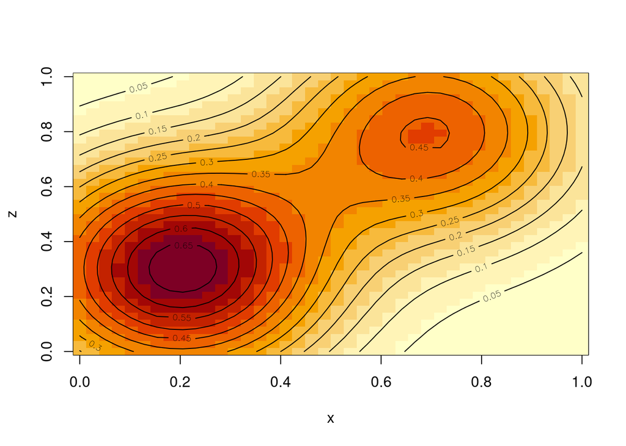

```r
truth <- dat$truth
dat <- dat$data

image(truth$f, xlab = "x", ylab = "z")
contour(truth$x, truth$z, truth$f, add = TRUE)
```

Fitting Gaussian GAM using standard GAM methods:

```r
tic <- proc.time()

fit <- gam(y ~ s(x, z, k = 100), data = dat)

( proc.time() - tic )[3]
```

```
## elapsed
##  28.345
```

```r
library(profmem)
prof <- profmem( gam(y ~ s(x, z, k = 100), data = dat) )
head(prof)
```

```
## Rprofmem memory profiling of:
## gam(y ~ s(x, z, k = 100), data = dat)
##
## Memory allocations:
##        what   bytes
## 1     alloc     200
## 2     alloc     200
## 3     alloc  400048
## 4     alloc  400048
## 5     alloc  400048
## 6     alloc  400048
## total       1600592
##                                                                                                                     calls
## 1                                                                                     gam() -> do.call() -> gam.control()
## 2                                                                                     gam() -> do.call() -> gam.control()
## 3     gam() -> eval() -> eval() -> <Anonymous> -> model.frame.default() -> na.omit() -> na.omit.data.frame() -> logical()
## 4                  gam() -> eval() -> eval() -> <Anonymous> -> model.frame.default() -> na.omit() -> na.omit.data.frame()
## 5                  gam() -> eval() -> eval() -> <Anonymous> -> model.frame.default() -> na.omit() -> na.omit.data.frame()
## 6                  gam() -> eval() -> eval() -> <Anonymous> -> model.frame.default() -> na.omit() -> na.omit.data.frame()
## total
```

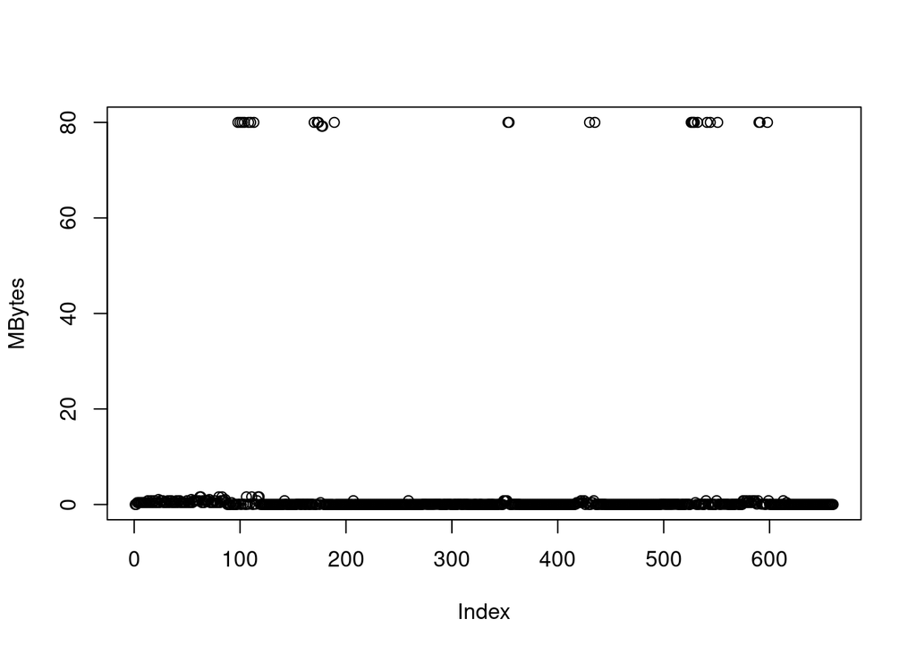

```r
alloc <- prof$bytes[!is.na(prof$bytes) & prof$what == "alloc"] / 1e6
plot(alloc, ylab = "MBytes")
```

```r
sum( alloc ) # MBytes
```

```
## [1] 2331.379
```

`gam` allocated few big memory chunks!

Fitting same GAM using Big Data methods:

```r
tic <- proc.time()

fit <- bam(y ~ s(x, z, k = 100), data = dat, discrete = TRUE, nthreads = 2)

( proc.time() - tic )[3]
```

```
## elapsed
##   4.071
```

Much faster! Let’s look at memory usage:

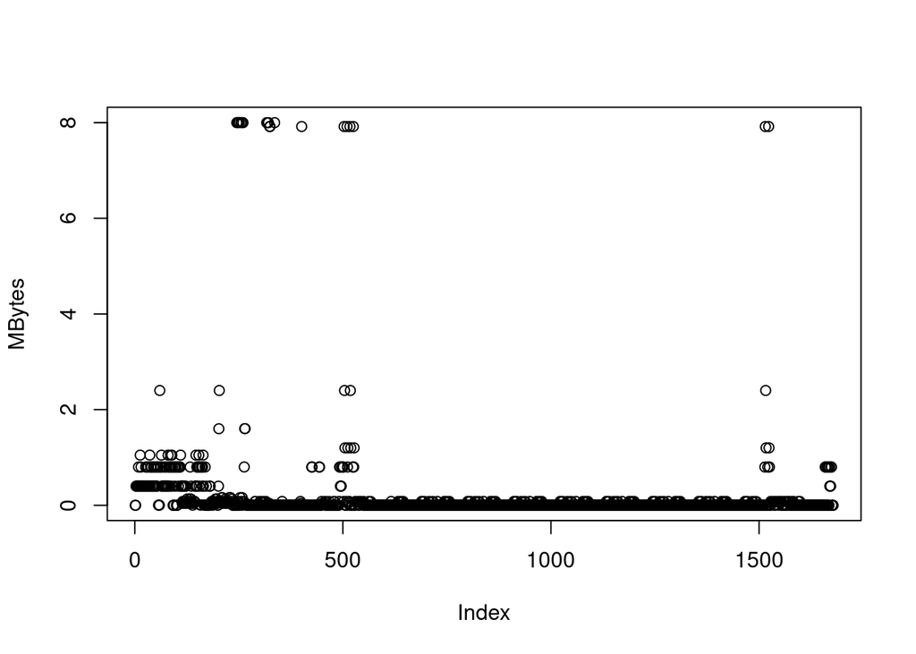

```r
prof <- profmem(bam(y ~ s(x, z, k = 100), data = dat, discrete = TRUE, nthreads = 2))

alloc <- prof$bytes[!is.na(prof$bytes) & prof$what == "alloc"] / 1e6
plot(alloc, ylab = "MBytes")
```

```r
sum( alloc ) # MBytes
```

```
## [1] 307.3589
```

Memory allocation has decreased dramatically!

Working with `bam` and `mgcViz`:

```r
fit <- bam(y ~ s(x, z, k = 100), data = dat, discrete = TRUE, nthreads = 2)
fit <- getViz(fit, nsim = 50)
```

Equivalent to doing:

```r
fit <- bamV(y ~ s(x, z, k = 100),
            data = dat,
            aGam = list(discrete = TRUE,  # arguments going to bam(). See ?bam
                        nthreads = 2),
            aViz = list(nsim = 50)        # arguments going to getViz(). See ?getViz
            )
```

Plotting the smooth effect:

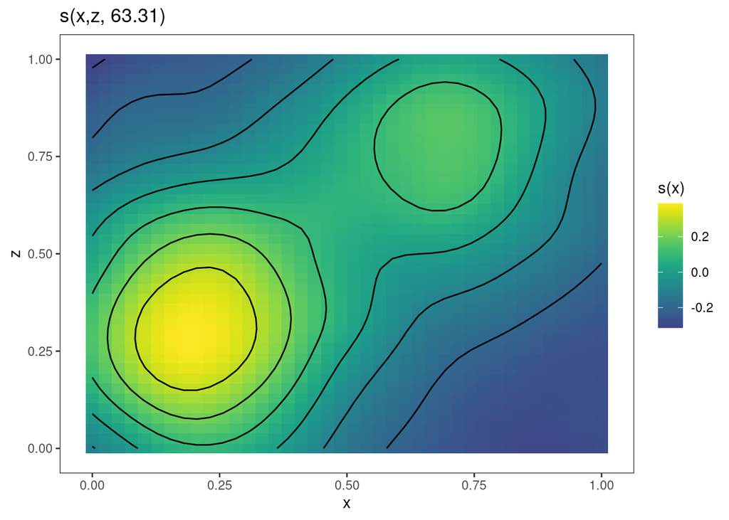

```r
plot(fit)
```

We can also extract the effect and plot it interactively:

```r
plotRGL(sm(fit, 1), residuals = TRUE)
```

[interactive chart not shown]

Only a sub-sample of the residuals is plotted (see `?plotRGL`, `maxpo` argument in particular).

Plotting methods in `mgcViz` are meant to work with big data sets. Consider example:

```r
x <- rnorm(1e6)
myDat <- data.frame(x = x, y = 0.5*x^2 + rnorm(1e6))

fit <- bam(y ~ s(x), data = myDat, discrete = TRUE)
```

Some residuals checks:

```
##
## Method: fREML   Optimizer: perf chol
## $grad
## [1]  1.208765e-05 -1.222541e-05
##
## $hess
##        [,1]          [,2]
##    3.964971     -3.975358
## d -3.975358 499999.000012
##
## Model rank =  10 / 10
##
## Basis dimension (k) checking results. Low p-value (k-index<1) may
## indicate that k is too low, especially if edf is close to k'.
##
##        k'  edf k-index p-value
## s(x) 9.00 8.95    0.99    0.21
```

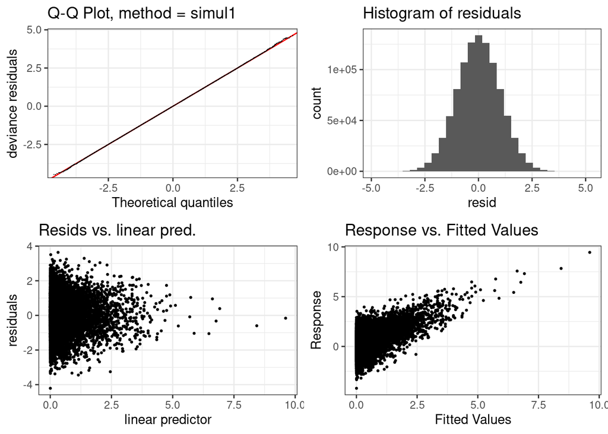

```r
fit <- getViz(fit)

tic <- proc.time()
check(fit)   # calls check.gamViz() from mgcViz
```

```r
( proc.time() - tic )[3]
```

```
## elapsed
##   4.884
```

the QQ-plot is discretized (see `?qq.gamViz`) and the other plots show only sub-samples.

Rendering the plots produced using `mgcv::gam.check` might freeze your session:

```r
tic <- proc.time()
gam.check(fit)
```

```
##
## Method: fREML   Optimizer: perf chol
## $grad
## [1]  1.208765e-05 -1.222541e-05
##
## $hess
##        [,1]          [,2]
##    3.964971     -3.975358
## d -3.975358 499999.000012
##
## Model rank =  10 / 10
##
## Basis dimension (k) checking results. Low p-value (k-index<1) may
## indicate that k is too low, especially if edf is close to k'.
##
##        k'  edf k-index p-value
## s(x) 9.00 8.95       1     0.6
```

```r
( proc.time() - tic )[3]
```

```
## elapsed
##  49.979
```

because each of the $10^6$ data points is rendered.

# References

Wood S. N. (2017) Generalized additive models: an introduction with R. Second edition. Chapman and Hall/CRC, 2017.